# BIOS 667 - Lecture 16: Contrasting Marginal and Mixed Effects Models

Fitzmaurice, Laird & Ware (2011) - Applied Longitudinal Data Analysis

Naim Rashid

2026-10-06

## Lecture Objectives

- Distinguish between **population-average** (marginal) and **subject-specific** (conditional) estimands
- Explain why marginal and mixed models yield identical fixed effects for **linear** models but diverge for **non-linear** link functions
- Apply the **attenuation formula** to relate GLMM coefficients to GEE coefficients in logistic models
- Analyze the **ECG crossover case study** using both GEE and GLMM, interpreting differences in treatment effect estimates
- Select the appropriate modeling framework based on the **research question and audience**

## Roadmap

1. Key terminology and conceptual framework
2. The linear model special case (equivalence)
3. Non-linear links and the attenuation phenomenon
4. ECG crossover case study (GEE vs GLMM)
5. Decision framework: when to use which approach
6. Common misconceptions and best practices

## Notation reference

| Symbol | Meaning |
| --- | --- |
| $Y_{ij}$ | response for subject $i$ at occasion $j$ (scalar) |
| $\mathbf{Y}_i$ | response vector for subject $i$ $(n_i \times 1)$ |
| $\mathbf{X}_i,\ \boldsymbol\beta$ | fixed-effect design $n_i \times p$ and coefficients |
| $\mathbf{Z}_i,\ \mathbf{b}_i$ | random-effect design and random effects, $\mathbf{b}_i \sim N(0, G)$ |
| $G$ | between-subject random-effects covariance (FLW’s letter, Ch. 8) |
| $R_i$ | within-subject residual covariance, $\boldsymbol\varepsilon_i \sim N(0, R_i)$ |
| $\Sigma_i = \mathbf{Z}_i G \mathbf{Z}_i^\top + R_i$ | marginal (total) covariance $\operatorname{Cov}(\mathbf{Y}_i)$ for subject $i$ |
| $\rho$ | correlation parameter (AR(1), exchangeable) |

Indices: $i$ subject $1,\dots,N$; $j$ occasion/time $1,\dots,n_i$ ($n$ when balanced); $k$ state (transition models); $g$ group. **Bold** = vector or matrix.

## Notation (this lecture)

| Symbol | Meaning |
| --- | --- |
| $\boldsymbol\beta$ | marginal / population-average coefficients: $g(\mu_i)=\mathbf{X}_i\boldsymbol\beta$ |
| $\boldsymbol\beta^*$ | conditional / subject-specific coefficients: $g\{\operatorname{E}(Y_i\mid \mathbf{b}_i)\}=\mathbf{X}_i\boldsymbol\beta^* + \mathbf{Z}_i\mathbf{b}_i$ |
| $\sigma_b^2$ | random-intercept variance ($=g_{11}$, the single element of $G$ with one random intercept) |
| $h(\cdot)$ | inverse link $h=g^{-1}$; for logistic $h=\operatorname{expit}=\operatorname{logit}^{-1}=\texttt{plogis}$ |
| $c$ | attenuation factor relating $\boldsymbol\beta$ to $\boldsymbol\beta^*$ (logistic random intercept) |
| $\pi_{ij}$ | $P(Y_{ij}=1)$, binary success probability (from L11) |
| $\alpha$ | GEE working-correlation / log-OR association parameter (from L13) |

## Key Terminology

| Term | Definition |
| --- | --- |
| **Estimand** | The population quantity we seek to estimate (e.g., population odds ratio) |
| **Estimator** | The statistical method/procedure that produces a number (e.g., GEE coefficient) |
| **Estimate** | The actual number obtained from applying the estimator to data |
| **Non-collapsibility**$^\dagger$ | Marginal OR $\neq$ conditional OR even without confounding (binary outcomes) |
| **Attenuation** | Reduction in marginal effect magnitude vs conditional effect due to averaging over random effects |

$^\dagger$ Beyond FLW Ch. 16 (the chapter frames the same gap purely as different *targets of inference* plus attenuation of $\boldsymbol\beta^*$ relative to $\boldsymbol\beta$). “Non-collapsibility” is the standard term from Greenland, Robins & Pearl (1999) and Agresti (2002, Section 12.2, which FLW cites); we use it as a labeled aside.

## Visual Decision Framework

```
                    Research Question
                 What is the target of inference?
                    /                \
          Population Effect?     Individual Effect?
                 |                      |
          Marginal Model (GEE)    Mixed Model (GLMM)
                 |                      |
         Population OR/RR         Subject-specific OR/RR
```

**Key insight**: Choose your estimand BEFORE choosing your software.

## The Fundamental Distinction

Imagine 1000 patients with hypertension starting a new drug.

| Question Type | Question | Model |
| --- | --- | --- |
| **Population-average** | If we give this drug to all 1000 patients, what is the average reduction in systolic BP? | Marginal (GEE) |
| **Subject-specific** | For Patient #247 in my clinic, how much will *her* BP change? | Mixed (GLMM) |

## When Differences Are Largest

**These are different questions requiring different models.**

Divergence is greatest when:

- Outcomes are **non-linear** (binary, count data)
- There is **high between-subject heterogeneity** ($\sigma_b^2$ is large)

## Concrete Example: Smoking Cessation

A new smoking cessation program is being evaluated:

| Model | Odds Ratio | Interpretation |
| --- | --- | --- |
| GLMM | 3.0 | Individual’s odds of quitting triple |
| GEE | 2.0 | Population odds of quitting double |

**Why the difference?** High variability in individual responses.

## Concrete Example: Who Uses Which?

| Stakeholder | Uses OR | Reason |
| --- | --- | --- |
| FDA | 2.0 (GEE) | “What’s the population benefit?” |
| Clinician | 3.0 (GLMM) | “Will this help my patient?” |

Both estimates are correct for their intended purpose.

## Packages for Today

```r
required_pkgs <- c("dplyr", "tidyr", "ggplot2", "geepack", "lme4", "broom.mixed", "survival")
missing_pkgs <- required_pkgs[!vapply(required_pkgs, requireNamespace, logical(1), quietly = TRUE)]
if (length(missing_pkgs) > 0) {
  stop(
    "Please install the following packages before rendering: ",
    paste(missing_pkgs, collapse = ", ")
  )
}
invisible(lapply(required_pkgs, library, character.only = TRUE))
```

## Packages for Today

## Connecting to Earlier Lectures

| Lecture | Topic | Key Point |
| --- | --- | --- |
| L08-10 | Linear Mixed Models | $\beta$ has marginal interpretation; GLS and LMM give same population inference |
| L12-13 | GEE | Population-average approach; focus on $\mu_i = \operatorname{E}(Y_i)$ |
| L14-15 | GLMMs | Subject-specific approach; focus on $\operatorname{E}(Y_i \mid b_i)$ |
| **Today** | Contrast | Why these yield DIFFERENT answers for non-linear models |

## The Key Realization

The “equivalence” we enjoyed with linear models (GLS $\approx$ LME for $\beta$) **BREAKS DOWN** completely once we introduce non-linear link functions.

**Central question**: When do population-average and subject-specific parameters diverge, by how much, and which one should you report?

# Part I: Concepts and the Linear Special Case

## 16.1 The Main Idea

- Marginal and mixed models differ **beyond** correlation handling; they answer different questions.
- Linear models mask this difference because $\operatorname{E}(Y_i)=X_i\beta$ either way.
- Once the link is non-linear, $\beta$ (population) and $\beta^*$ (subject) diverge.
- Always start by writing down the estimand **before** picking software.

## 16.2 Linear Special Case: Why Equivalence Holds

With identity link, both GLS and LME imply $\operatorname{E}(Y_i)=X_i\beta$.

**Why?** Averaging a linear function of $b_i$ is straightforward:
$$\operatorname{E}[Z_i b_i] = Z_i \operatorname{E}(b_i) = 0$$

Random effects only restructure the covariance:
$$\boldsymbol\Sigma_i = \mathbf{Z}_i G \mathbf{Z}_i^\top + \sigma^2 \mathbf{I}$$

where $G$ is the between-subject random-effects covariance and $\sigma^2 \mathbf{I}$ is the within-subject measurement (error) covariance.

Therefore $\boldsymbol\beta$ retains a marginal interpretation in linear mixed models: here $\boldsymbol\beta = \boldsymbol\beta^*$.

## 16.2 Quick Derivation

Start from the LME conditional mean:
$$\operatorname{E}(\mathbf{Y}_i \mid \mathbf{b}_i) = \mathbf{X}_i\boldsymbol\beta + \mathbf{Z}_i \mathbf{b}_i$$

Apply law of total expectation:
$$\operatorname{E}(\mathbf{Y}_i) = \operatorname{E}\big[\operatorname{E}(\mathbf{Y}_i \mid \mathbf{b}_i)\big]$$

Substitute:
$$\operatorname{E}(\mathbf{Y}_i) = \mathbf{X}_i\boldsymbol\beta + \mathbf{Z}_i \operatorname{E}(\mathbf{b}_i) = \mathbf{X}_i\boldsymbol\beta$$

when $\operatorname{E}(\mathbf{b}_i) = \mathbf{0}$.

## Why Non-Linearity Breaks Equivalence

**Mathematical reason**: Expectation is a linear operator.

| Operation | Result |
| --- | --- |
| $\operatorname{E}(a + b) = \operatorname{E}(a) + \operatorname{E}(b)$ | Works (linear) |
| $\operatorname{E}[h(a + b)] \neq h[\operatorname{E}(a) + \operatorname{E}(b)]$ | Jensen’s inequality |

where $h = g^{-1}$ is the inverse link (for logistic, $h = \operatorname{expit}$).

## Visual Intuition

| Case | What Happens |
| --- | --- |
| **Linear** | Individual lines (each with slope $\beta_1$) average to population line with same slope $\beta_1$ |
| **Logistic** | Individual S-curves (each with slope parameter $\beta_1^*$) average to flatter S-curve with smaller slope parameter $\beta$ |

**Plain English**: Averaging curved lines gives a different curve than the average line.

## 16.3 Link Function Consequences

Define marginal model: $g(\mu_i) = \mathbf{X}_i \boldsymbol\beta$ with $\mu_i = \operatorname{E}(Y_i)$.

Define GLMM: $g\{\operatorname{E}(Y_i\mid \mathbf{b}_i)\} = \mathbf{X}_i \boldsymbol\beta^* + \mathbf{Z}_i \mathbf{b}_i$.

Marginal mean requires integrating the inverse link $h$ over $\mathbf{b}_i$:
$$\mu_i = \int h(\mathbf{X}_i\boldsymbol\beta^* + \mathbf{Z}_i \mathbf{b}_i)\, f(\mathbf{b}_i)\,d\mathbf{b}_i$$

**Result**: $g(\mu_i) \neq \mathbf{X}_i \boldsymbol\beta^*$ in general; the link form is not preserved.

## 16.3 Attenuation Insight

For a logistic GLMM with a random intercept:
$$\text{logit}\{\operatorname{E}(Y_{ij}\mid b_i)\} = X_{ij}\boldsymbol\beta^* + b_i, \qquad b_i \sim N(0,\sigma_b^2)$$

Approximate marginal relationship (Zeger, Liang & Albert, 1988; FLW p. 477):
$$\text{logit}\{\operatorname{E}(Y_{ij})\} \approx c \, X_{ij}\boldsymbol\beta^*, \qquad c = \left(1 + c_2^{\,2}\,\sigma_b^2\right)^{-1/2}$$

where the **named constant** is $c_2 = \dfrac{16\sqrt{3}}{15\pi} \approx 0.588$, so the **multiplier** of $\sigma_b^2$ is $c_2^{\,2} \approx 0.346$.

Thus $|\boldsymbol\beta| < |\boldsymbol\beta^*|$ whenever $\sigma_b^2 > 0$; attenuation grows with heterogeneity.

**Note**

Two numbers, one constant. $c_2 = 16\sqrt{3}/(15\pi) \approx 0.588$ is the named Zeger-Liang-Albert constant; the quantity that multiplies $\sigma_b^2$ inside the attenuation factor is $c_2^{\,2} \approx 0.346$. Some texts (and FLW p. 477) report the constant as $0.588$ and write the multiplier as $c_2^2 = 0.346$; the deck uses $0.346$ as the multiplier throughout.

## Important Note on the Attenuation Constant

The multiplier $c_2^{\,2} \approx 0.346$ is an **approximation specific to**:

- Logistic GLMMs with random intercepts
- Normally distributed random effects

Source: Zeger, Liang & Albert (1988); $c_2 = 16\sqrt{3}/(15\pi) \approx 0.588$.

**Does NOT apply to**: other link functions or random-slope models.

## Clinical Translation

> “Individual treatment effects look stronger than population effects because high responders and low responders average out.”

## 16.3 Attenuation Formula and Severity

$$\boldsymbol\beta_{\text{marginal}} \approx \frac{\boldsymbol\beta^*_{\text{GLMM}}}{\sqrt{1 + 0.346\,\sigma_b^2}}, \qquad c = \frac{1}{\sqrt{1 + 0.346\,\sigma_b^2}}$$

| $\sigma_b^2$ | Factor $c$ | Shrinkage | Severity |
| --- | --- | --- | --- |
| 0.5 | 0.92 | 8% | Mild |
| 2.0 | 0.77 | 23% | Noticeable |
| 4.0 | 0.65 | 35% | Substantial |
| 9.0 | 0.49 | 51% | Severe |

**Worked example** ($\boldsymbol\beta^* = 1.5$, $\sigma_b^2 = 4$): $\boldsymbol\beta_{\text{marg}} = 1.5/\sqrt{1 + 0.346(4)} = 1.5/1.544 \approx 0.97$ (factor $c=0.65$). Population OR $\approx 2.6$ vs individual OR $\approx 4.5$: same direction, weaker population effect.

## Check Your Understanding: Attenuation

**Question:** A researcher reports that a GLMM for diabetes progression yields a treatment OR of 0.5 (protective effect) with random intercept variance $\sigma_b^2 = 3.0$. They conclude: “Treatment cuts the population odds in half.”

**What is wrong with this conclusion, and what is the correct population OR?**

**Answer:** The researcher incorrectly interpreted the **conditional** OR as a **marginal** (population) effect.

**Calculation:**
$$\beta^{\text{marg}} = \frac{\log(0.5)}{\sqrt{1 + 0.346 \times 3.0}} = \frac{-0.693}{\sqrt{2.038}} = \frac{-0.693}{1.43} = -0.485$$

**Marginal OR** = $\exp(-0.485) = 0.62$

**Correct conclusion:** “Within individuals, treatment cuts odds in half (OR = 0.5). At the population level, treatment reduces odds by about 38% (OR = 0.62).”

The population effect is attenuated toward the null due to averaging over heterogeneity.

## 16.3 Log Link Exception

For log-link GLMMs:
$$\log \{\operatorname{E}(Y_{ij}\mid b_i)\} = X_{ij}\boldsymbol\beta^* + Z_{ij} b_i$$

Marginal mean factorizes:
$$\mu_{ij} = \exp(X_{ij}\boldsymbol\beta^*)\, \operatorname{E}\{\exp(Z_{ij} b_i)\}$$

For a single random intercept, $\log(\mu_{ij}) = X_{ij}\boldsymbol\beta^* + g_{11}/2$: fixed effects **not** in $Z_{ij}$ carry over unchanged (only the intercept shifts by $g_{11}/2$).

**Warning**

**Qualifier (same slide, do not skip):** this clean carry-over holds **only** when the covariate has **no random slope** (it does not overlap $Z_{ij}$) **and** is independent of $b_i$. With a random slope present, fixed-effect rate ratios do **NOT** carry over unchanged.

## Important Clarification: Marginal Predictions from GLMMs

**Common misconception**: `predict(glmer_fit, re.form = NA)` gives marginal predictions.

**Reality** (FLW textbook, p. 477):

- `re.form = NA` gives **conditional predictions at $b_i = 0$** (the “typical” subject)
- For non-linear links: $\operatorname{E}(Y \mid b = 0) \neq \operatorname{E}(Y)$
- True marginal predictions require **integrating over the random effects distribution**

## Helper Function for True Marginal Predictions

```r
# CAVEAT: this helper assumes a SINGLE random intercept and a BINOMIAL family.
# It does NOT handle random slopes or non-binomial GLMMs.
glmm_marginal_prob <- function(fit, newdata, draws = 2000, seed = 667) {
  stopifnot(family(fit)$family == "binomial")
  set.seed(seed)  # reproducible Monte Carlo (course seed 667)
  # Fixed-part linear predictor at b = 0 (re.form = NA): X*beta-star only
  eta_fix <- predict(fit, newdata = newdata, re.form = NA, type = "link")
  # VarCorr(fit)[[1]] is the covariance of the FIRST grouping factor; its
  # "stddev" attribute is the random-intercept SD (a 1x1 here -> sigma_b).
  sd_b <- as.numeric(attr(VarCorr(fit)[[1]], "stddev"))
  # Monte Carlo integration over b ~ N(0, sigma_b^2): for each of `draws`
  # random intercepts, push eta_fix + b through plogis (= expit = h), then
  # average the probabilities across draws (rowMeans over the draw columns).
  rowMeans(sapply(1:draws, function(...) plogis(eta_fix + rnorm(1, 0, sd_b))))
}
```

## Helper Function for True Marginal Predictions

## Logistic Attenuation: Simulation Setup

```r
set.seed(667)
# Subject-specific parameters (conditional on random effects)
beta0 <- -1.5        # Log-odds at time=0 for average individual
beta1 <- 0.75        # Subject-specific slope (change per unit time)
sigma_b <- 2         # SD of random intercepts (heterogeneity); variance = 4

# Time grid for plotting
time_grid <- seq(-4, 8, by = 0.25)

# Simulate 25 individuals with varying intercepts
subject_b <- rnorm(25, mean = 0, sd = sigma_b)

# Generate subject-specific curves
subject_curves <- tidyr::expand_grid(time = time_grid, b = subject_b) |>
  mutate(
    linear_predictor = beta0 + beta1 * time + b,
    prob = plogis(linear_predictor),
    curve_id = factor(round(b, 2))
  )

# Generate marginal curve by Monte Carlo integration
marginal_curve <- tibble(
  time = time_grid,
  prob = vapply(
    time_grid,
    function(t) mean(plogis(beta0 + beta1 * t + rnorm(2000, 0, sigma_b))),
    numeric(1)
  )
)
```

## Logistic Attenuation: Simulation Setup

## Logistic Attenuation: Visualization

```r
logit_plot <- ggplot(subject_curves, aes(x = time, y = prob, group = curve_id)) +
  geom_line(alpha = 0.35, color = "#1f77b4") +
  geom_line(data = marginal_curve, aes(x = time, y = prob),
            inherit.aes = FALSE, color = "#d62728", linewidth = 1.2) +
  coord_cartesian(ylim = c(0, 1)) +
  labs(
    x = "Time",
    y = "Probability of success",
    title = "Subject-specific vs marginal logistic curves",
    subtitle = "Random intercept variance = 4; slopes attenuate after averaging"
  ) +
  theme_minimal(base_size = 16)
print(logit_plot)
```

## Logistic Attenuation: Visualization

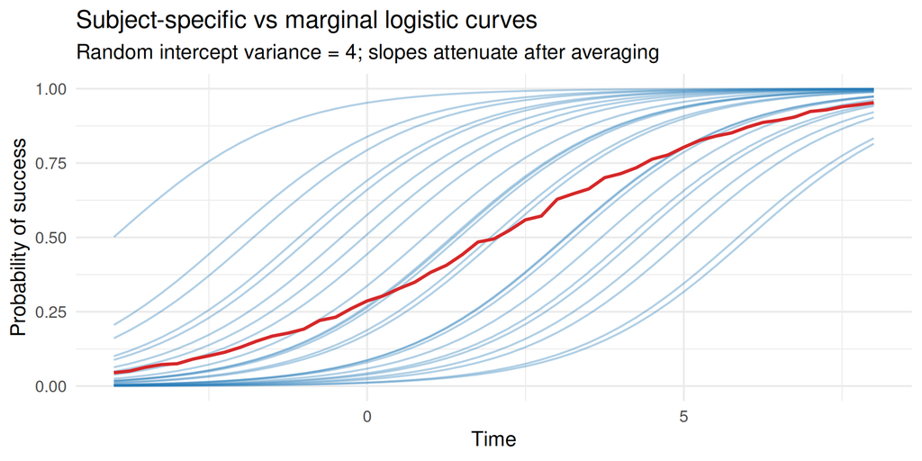

Conditional curves (blue) rise faster than the marginal mean (red). Subject-specific slope = 0.75 yields flatter population slope.

## Effect of Heterogeneity on Marginal Curves

```r
# Low heterogeneity (variance = 0.5)
sigma_b_low <- sqrt(0.5)
marginal_low <- tibble(
  time = seq(-4, 8, 0.5),
  prob = vapply(seq(-4, 8, 0.5),
                function(t) mean(plogis(beta0 + beta1 * t + rnorm(1000, 0, sigma_b_low))),
                numeric(1)),
  heterogeneity = "Low (var=0.5)"
)

# High heterogeneity (variance = 9)
sigma_b_high <- 3
marginal_high <- tibble(
  time = seq(-4, 8, 0.5),
  prob = vapply(seq(-4, 8, 0.5),
                function(t) mean(plogis(beta0 + beta1 * t + rnorm(1000, 0, sigma_b_high))),
                numeric(1)),
  heterogeneity = "High (var=9)"
)

# Plot comparison
comparison_plot <- ggplot() +
  geom_line(data = marginal_low, aes(x = time, y = prob),
            color = "#2ca02c", linewidth = 1.5) +
  geom_line(data = marginal_high, aes(x = time, y = prob),
            color = "#ff7f0e", linewidth = 1.5) +
  labs(title = "Impact of heterogeneity on marginal curves",
       subtitle = "Green: Low heterogeneity (steep) | Orange: High heterogeneity (flat)",
       x = "Time", y = "Probability") +
  theme_minimal(base_size = 14)
print(comparison_plot)
```

## Effect of Heterogeneity on Marginal Curves

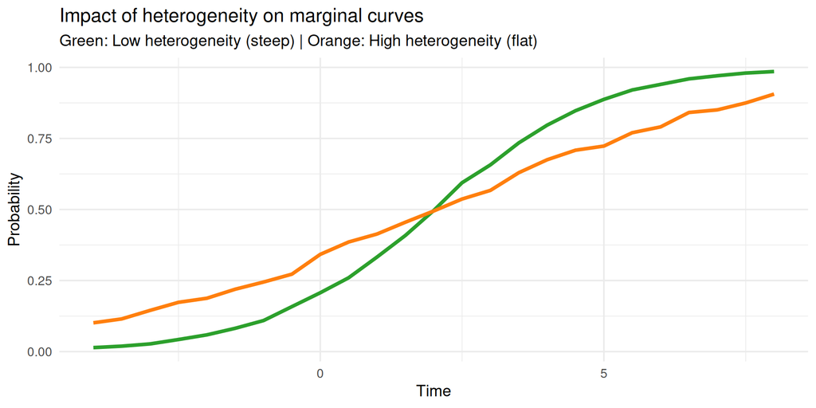

## Logistic Attenuation: Key Observations

| Observation | Explanation |
| --- | --- |
| Subject curves (blue) are steeper | They condition on individual $b_i$ |
| Marginal curve (red) is flatter | Averaging shrinks the slope because logit is non-linear |
| Higher $\sigma_b^2$ = more attenuation | More heterogeneity to average over |
| Direction preserved | Magnitude shrinks toward null |

## 16.4 Simple Numerical Illustration

Consider a simple setting: binary responses depend only on time with a random intercept.

**GLMM (conditional model)**:
$$\text{logit}\{P(Y_{ij} = 1 \mid b_i)\} = \beta_0^* + \beta_1^* t_{ij} + b_i, \quad b_i \sim N(0, \sigma_b^2)$$

**Key insight**: The conditional slope $\beta_1^*$ describes how an *individual’s* log-odds changes over time.

## 16.4 Why Marginal Slope Differs

To obtain the **marginal** (population-average) probability, we must integrate:
$$P(Y_{ij} = 1) = \int \text{expit}(\beta_0^* + \beta_1^* t_{ij} + b_i) \, \phi(b_i; 0, \sigma_b^2) \, db_i$$

**Critical point**: Due to the non-linearity of expit(), this integral does NOT simplify to:
$$\text{logit}\{P(Y_{ij} = 1)\} = \beta_0 + \beta_1 t_{ij}$$

with $\beta_1 = \beta_1^*$. Instead, $|\beta_1| < |\beta_1^*|$.

## 16.4 The b=0 Misconception

**Common error**: Claiming that setting $b_i = 0$ in a GLMM gives marginal predictions.

**Why this is wrong** (FLW textbook, p. 477):
$$\operatorname{E}[Y \mid b = 0] \neq \operatorname{E}[Y]$$

For non-linear links, the conditional expectation at the mean of $b$ is NOT the marginal expectation.

## 16.4 Demonstration: b=0 vs True Marginal

```r
# Parameters
beta0 <- 0
beta1 <- 1
sigma_b <- 2  # variance = 4

# Time points
t_vals <- seq(-3, 3, by = 0.5)

# Prediction at b = 0 (the WRONG "marginal")
prob_b0 <- plogis(beta0 + beta1 * t_vals)

# True marginal (integrate over random effects)
prob_marginal <- sapply(t_vals, function(t) {
  mean(plogis(beta0 + beta1 * t + rnorm(5000, 0, sigma_b)))
})

# Compare
comparison_df <- data.frame(
  time = t_vals,
  prob_b0 = prob_b0,
  prob_marginal = prob_marginal,
  difference = prob_b0 - prob_marginal
)

cat("Comparison of P(Y=1|b=0) vs true E[Y]:\n")
```

## 16.4 Demonstration: b=0 vs True Marginal

```
Comparison of P(Y=1|b=0) vs true E[Y]:
```

```r
print(round(comparison_df, 3))
```

```
   time prob_b0 prob_marginal difference
1  -3.0   0.047         0.129     -0.081
2  -2.5   0.076         0.179     -0.103
3  -2.0   0.119         0.220     -0.101
4  -1.5   0.182         0.283     -0.100
5  -1.0   0.269         0.356     -0.087
6  -0.5   0.378         0.421     -0.044
7   0.0   0.500         0.489      0.011
8   0.5   0.622         0.581      0.042
9   1.0   0.731         0.648      0.083
10  1.5   0.818         0.713      0.105
11  2.0   0.881         0.773      0.108
12  2.5   0.924         0.822      0.103
13  3.0   0.953         0.873      0.079
```

## 16.4 Visual Comparison

```r
ggplot(comparison_df, aes(x = time)) +
  geom_line(aes(y = prob_b0), color = "#1f77b4", linetype = "dashed", linewidth = 1.2) +
  geom_line(aes(y = prob_marginal), color = "#d62728", linewidth = 1.2) +
  annotate("text", x = 2, y = 0.9, label = "P(Y=1 | b=0)", color = "#1f77b4", size = 5) +
  annotate("text", x = 2, y = 0.65, label = "True E[Y]", color = "#d62728", size = 5) +
  labs(
    x = "Time",
    y = "Probability",
    title = "Conditional at b=0 vs True Marginal Probability",
    subtitle = expression(paste("GLMM with ", sigma[b], " = 2; b=0 overestimates probabilities near 0.5"))
  ) +
  coord_cartesian(ylim = c(0, 1)) +
  theme_minimal(base_size = 14)
```

## 16.4 Visual Comparison

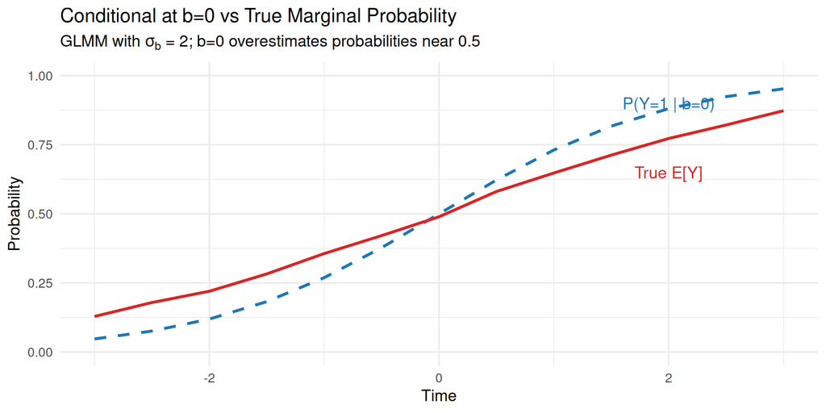

[figure not shown]

**Note**

**Direction of bias (Jensen):** expit is concave above $p=0.5$ and convex below, so averaging over $b_i$ pulls the marginal probability **toward 0.5**. The marginal slope is therefore flatter than the subject-specific slope: $|\boldsymbol\beta| < |\boldsymbol\beta^*|$.

## Difference Near p = 0.5: When It Matters

[output not shown]

## 16.4 Key Takeaway

| Prediction Type | What It Represents | How to Compute |
| --- | --- | --- |
| `re.form = NA` | $E[Y \mid b = 0]$ (typical subject) | `predict(fit, re.form = NA)` |
| True marginal | $E[Y]$ (population average) | Integrate over $f(b)$ |

This bridges to the ECG crossover case study where we compare GEE vs GLMM estimates.

# Part II: ECG Case Study and Choosing a Model

## 16.5 ECG Crossover Overview

**Study design** (FLW Table 16.1; Jones & Kenward 1989):

- 67 patients randomized to sequences: Placebo$\to$Active (34) or Active$\to$Placebo (33)
- Binary response each period: abnormal ECG (1) vs normal (0)
- Sampling zero in Sequence 1, pattern (1,0) - sparse cell issue

**Goal**: Compare treatment effect estimates from marginal vs mixed models.

## ECG Crossover: Key Questions

| Stakeholder | Question |
| --- | --- |
| FDA | “What’s the population risk increase if we approve this drug?” |
| Clinician | “Should I prescribe this to my patient with cardiac history?” |

## 16.5 Crossover Design: Sequence x Period -> Treatment

```
                Period 1        Period 2
            +-------------+   +-------------+
 Seq P->A   |  Placebo    |   |  Active     |   treatment = 0, then 1
 (34 pts)   |  (trt = 0)  |   |  (trt = 1)  |
            +-------------+   +-------------+
 Seq A->P   |  Active     |   |  Placebo    |   treatment = 1, then 0
 (33 pts)   |  (trt = 1)  |   |  (trt = 0)  |
            +-------------+   +-------------+
```

Each subject contributes **two** binary ECG responses; `treatment` is the active/placebo indicator for that period, decoded from (sequence, period).

## 16.5 Data Reconstruction

```r
ecg_counts <- tribble(
  ~sequence, ~resp_p1, ~resp_p2, ~count,
  "P-A", 1, 1, 6,
  "P-A", 1, 0, 0,  # Sampling zero
  "P-A", 0, 1, 6,
  "P-A", 0, 0, 22,
  "A-P", 1, 1, 9,
  "A-P", 1, 0, 4,
  "A-P", 0, 1, 2,
  "A-P", 0, 0, 18
)

ecg_long <- ecg_counts |>
  tidyr::uncount(count) |>
  # one UNIQUE subject id per expanded row (67 patients, 2 rows each).
  # Do NOT reuse uncount's within-cell .id: that repeats ids across cells.
  mutate(id = factor(row_number())) |>
  tidyr::pivot_longer(
    cols = c(resp_p1, resp_p2),
    names_to = "period",
    values_to = "response"
  ) |>
  mutate(
    period = if_else(period == "resp_p1", 1L, 2L),
    # decode active-drug indicator from (sequence, period); see schematic
    treatment = case_when(
      sequence == "P-A" & period == 1L ~ 0L,
      sequence == "P-A" & period == 2L ~ 1L,
      sequence == "A-P" & period == 1L ~ 1L,
      TRUE ~ 0L
    )
  ) |>
  arrange(id, period)

cat("Subjects:", length(unique(ecg_long$id)),
    "| rows:", nrow(ecg_long), "\n\n")
```

## 16.5 Data Reconstruction

```
Subjects: 67 | rows: 134
```

```r
cat("Reshaped long table (first 6 rows):\n")
```

```
Reshaped long table (first 6 rows):
```

```r
head(ecg_long)
```

```
# A tibble: 6 × 5
  sequence id    period response treatment
  <chr>    <fct>  <int>    <dbl>     <int>
1 P-A      1          1        1         0
2 P-A      1          2        1         1
3 P-A      2          1        1         0
4 P-A      2          2        1         1
5 P-A      3          1        1         0
6 P-A      3          2        1         1
```

## 16.5 Model Fits: GEE

```r
# Marginal model (GEE), exchangeable working correlation
gee_fit <- geepack::geeglm(
  response ~ treatment + period,
  id = id,
  family = binomial,
  corstr = "exchangeable",
  data = ecg_long
)
# Note: only 2 obs/subject, so robust SEs can be biased downward
# (small-sample corrections shown later).
summary(gee_fit)
```

**Note**

**Fidelity note.** FLW Table 16.2 fits the marginal model with the within-subject **association** modeled as a common **log odds ratio** $\alpha$ (an ALR-type GEE), reporting $\hat\alpha = 3.56$. We use an exchangeable working *correlation* as a close software substitute; the treatment estimate (log-odds $\approx 0.57$, OR $\approx 1.77$) reproduces FLW Table 16.2, but the association is parameterized differently.

## 16.5 Model Fits: GEE

```
Call:
geepack::geeglm(formula = response ~ treatment + period, family = binomial,
    data = ecg_long, id = id, corstr = "exchangeable")

 Coefficients:
            Estimate Std.err   Wald Pr(>|W|)
(Intercept)  -1.5298  0.4395 12.116   0.0005 ***
treatment     0.5689  0.2327  5.975   0.0145 *
period        0.2950  0.2311  1.629   0.2018
---
Signif. codes:  0 '***' 0.001 '**' 0.01 '*' 0.05 '.' 0.1 ' ' 1

Correlation structure = exchangeable
Estimated Scale Parameters:

            Estimate Std.err
(Intercept)   0.9975  0.1111
  Link = identity

Estimated Correlation Parameters:
      Estimate Std.err
alpha   0.6243  0.1286
Number of clusters:   67  Maximum cluster size: 2
```

## 16.5 Model Fits: GLMM

```r
# Mixed model (GLMM): 100-point adaptive Gaussian quadrature (FLW Table 16.3).
# Laplace (nAGQ = 1) is inadequate here because Var(b) is very large (~24).
glmm_fit <- lme4::glmer(
  response ~ treatment + period + (1 | id),
  family = binomial,
  data = ecg_long,
  nAGQ = 100,
  control = lme4::glmerControl(optimizer = "bobyqa", optCtrl = list(maxfun = 2e5))
)
summary(glmm_fit)
```

**Note**

**Fidelity note.** FLW Table 16.3 uses **100-point adaptive Gaussian quadrature** (`nAGQ = 100`). We match it. The default Laplace approximation (`nAGQ = 1`) is unreliable when $\widehat{\operatorname{Var}}(b_i)$ is as large as here (about 24), so it is not used.